# Lab 05 - Data Wrangling

# Learning goals

- Use the `merge()` function to join two datasets.
- Deal with missings and impute data.
- Identify relevant observations using `quantile()`.
- Practice your GitHub skills.

# Lab description

For this lab we will be dealing with the meteorological dataset `met`. In this case, we will use `data.table` to answer some questions regarding the `met` dataset, while at the same time practice your Git+GitHub skills for this project.

This markdown document should be rendered using `github_document` document.

# Part 1: Setup a Git project and the GitHub repository

1. Go to wherever you are planning to store the data on your computer, and create a folder for this project
2. In that folder, save [this template](https://github.com/JSC370/JSC370-2025/blob/main/labs/lab05/lab05-wrangling-gam.Rmd) as “README.Rmd”. This will be the markdown file where all the magic will happen.
3. Go to your GitHub account and create a new repository of the same name that your local folder has, e.g., “JSC370-labs”.
4. Initialize the Git project, add the “README.Rmd” file, and make your first commit.
5. Add the repo you just created on GitHub.com to the list of remotes, and push your commit to origin while setting the upstream.

Most of the steps can be done using command line:

```bash
# Step 1
cd ~/Documents
mkdir JSC370-labs
cd JSC370-labs

# Step 2
wget https://raw.githubusercontent.com/JSC370/jsc370-2023/main/labs/lab05/lab05-wrangling-gam.Rmd
mv lab05-wrangling-gam.Rmd README.Rmd
# if wget is not available,
curl https://raw.githubusercontent.com/JSC370/jsc370-2023/main/labs/lab05/lab05-wrangling-gam.Rmd --output README.Rmd

# Step 3
# Happens on github

# Step 4
git init
git add README.Rmd
git commit -m "First commit"

# Step 5
git remote add origin git@github.com:[username]/JSC370-labs
git push -u origin master
```

You can also complete the steps in R (replace with your paths/username when needed)

```r
# Step 1
setwd("~/Documents")
dir.create("JSC370-labs")
setwd("JSC370-labs")

# Step 2
download.file(
  "https://raw.githubusercontent.com/JSC370/jsc370-2023/main/labs/lab05/lab05-wrangling-gam.Rmd",
  destfile = "README.Rmd"
  )

# Step 3: Happens on Github

# Step 4
system("git init && git add README.Rmd")
system('git commit -m "First commit"')

# Step 5
system("git remote add origin git@github.com:[username]/JSC370-labs")
system("git push -u origin master")
```

Once you are done setting up the project, you can now start working with the MET data.

## Setup in R

1. Load the `data.table` (and the `dtplyr` and `dplyr` packages).

```r
library(data.table)
library(dtplyr)
library(dplyr)
library(mgcv)
library(leaflet)
library(tidyverse)
```

```r
library(ggplot2)
# install.packages("kableExtra")
library(kableExtra)
met <- data.table::fread("../lab03/met_all.gz")
```

2. Load the met data from https://raw.githubusercontent.com/JSC370/JSC370-2024/main/data/met_all_2023.gz, and also the station data. For the latter, you can use the code we used during lecture to pre-process the stations data:

```r
# Download the data
stations <- fread("ftp://ftp.ncdc.noaa.gov/pub/data/noaa/isd-history.csv")
stations[, USAF := as.integer(USAF)]
# Dealing with NAs and 999999
stations[, USAF   := fifelse(USAF == 999999, NA_integer_, USAF)]
stations[, CTRY   := fifelse(CTRY == "", NA_character_, CTRY)]
stations[, STATE  := fifelse(STATE == "", NA_character_, STATE)]

# Selecting the three relevant columns, and keeping unique records
stations <- unique(stations[, list(USAF, CTRY, STATE)])

# Dropping NAs
stations <- stations[!is.na(USAF)]

# Removing duplicates
stations[, n := 1:.N, by = .(USAF)]
stations <- stations[n == 1,][, n := NULL]
```

3. Merge the data as we did during the lecture. Use the `merge()` code and you can also try the tidy way with `left_join()`

```r
stations[, n := 1:.N, by = .(USAF)]
stations <- stations[n == 1,][, n := NULL]

met_dt <- merge(
  x=met,
  y=stations,
  by.x="USAFID",
  by.y="USAF",
  all.x=TRUE,
  all.y=FALSE
)

## Alternative
# met_dt <- left_join(
#   x=met, y=stations,
#   by=c("USAFID" = "USAF")
# )
```

## Question 1: Representative station for the US

Across all weather stations, what stations have the median values of temperature, wind speed, and atmospheric pressure? Using the `quantile()` function, identify these three stations. Do they coincide?

```r
medians <- met_dt[, .(
  temp_50 = quantile(temp, probs = 0.5, na.rm=TRUE),
  wind.sp_50 = quantile(wind.sp, probs = 0.5, na.rm=TRUE),
  atm.press_50 = quantile(atm.press, probs = 0.5, na.rm=TRUE)
)]
medians
```

```
##    temp_50 wind.sp_50 atm.press_50
##      <num>      <num>        <num>
## 1:    23.5        2.1       1014.1
```

```r
station_med <- met_dt[, .(
  temp = quantile(temp, probs = 0.5, na.rm=TRUE),
  wind.sp = quantile(wind.sp, probs = 0.5, na.rm=TRUE),
  atm.press = quantile(atm.press, probs = 0.5, na.rm=TRUE),
  lat = mean(lat, nar.rm=TRUE),
  lon = mean(lon, nar.rm=TRUE)
), by = .(USAFID, STATE)]

# Median temperature stations
station_med[, temp_dist := abs(temp-medians$temp_50)]
median_temp_station <- station_med[temp_dist == 0]
median_temp_station
```

```
##    USAFID  STATE  temp wind.sp atm.press      lat       lon temp_dist
##     <int> <char> <num>   <num>     <num>    <num>     <num>     <num>
## 1: 720501     VA  23.5     1.5        NA 37.85000 -76.88300         0
## 2: 722031     AL  23.5     0.0        NA 34.26900 -86.85800         0
## 3: 722148     NC  23.5     0.0        NA 35.41700 -80.15100         0
## 4: 723055     NC  23.5     0.0        NA 35.76500 -80.95687         0
## 5: 723067     NC  23.5     1.5        NA 35.31801 -77.63127         0
## 6: 723177     NC  23.5     0.0        NA 36.46000 -80.55300         0
## 7: 725564     NE  23.5     2.6        NA 41.44900 -96.52000         0
```

```r
# Median wind speed stations
station_med[, wind.sp_dist := abs(wind.sp-medians$wind.sp_50)]
median_wind.sp_station <- station_med[wind.sp_dist == 0]
median_wind.sp_station
```

```
##      USAFID  STATE  temp wind.sp atm.press      lat       lon temp_dist
##       <int> <char> <num>   <num>     <num>    <num>     <num>     <num>
##   1: 720110     TX  31.0     2.1        NA 30.78400  -98.6620       7.5
##   2: 720258     MN  17.0     2.1        NA 46.61900  -93.3100       6.5
##   3: 720266     IN  21.0     2.1        NA 41.27500  -85.8400       2.5
##   4: 720272     WA  18.0     2.1        NA 48.46717 -122.4162       5.5
##   5: 720273     TX  28.6     2.1        NA 28.97300  -95.8630       5.1
##  ---
## 339: 726583     MN  21.0     2.1        NA 45.14115  -94.5070       2.5
## 340: 726589     MN  20.0     2.1        NA 43.68286  -93.3670       3.5
## 341: 726603     MN  20.7     2.1        NA 44.85700  -93.0330       2.8
## 342: 726626     WI  16.6     2.1        NA 45.15400  -89.1110       6.9
## 343: 726813     ID  22.8     2.1   1011.75 43.64963 -116.6331       0.7
##      wind.sp_dist
##             <num>
##   1:            0
##   2:            0
##   3:            0
##   4:            0
##   5:            0
##  ---
## 339:            0
## 340:            0
## 341:            0
## 342:            0
## 343:            0
```

```r
# Median atmosphere pressure stations
station_med[, atm.press_dist := abs(atm.press-medians$atm.press_50)]
median_atm.press_station <- station_med[atm.press_dist == 0]
median_atm.press_station
```

```
##     USAFID  STATE  temp wind.sp atm.press      lat        lon temp_dist
##      <int> <char> <num>   <num>     <num>    <num>      <num>     <num>
##  1: 722420     TX  30.0     4.6    1014.1 29.27298  -94.85900       6.5
##  2: 723830     CA  23.3     5.1    1014.1 34.74468 -118.72504       0.2
##  3: 724885     NV  24.7     2.6    1014.1 39.41700 -118.71577       1.2
##  4: 724940     CA  18.9     5.1    1014.1 37.61960 -122.36669       4.6
##  5: 725376     MI  22.8     3.1    1014.1 42.23315  -83.53291       0.7
##  6: 725975     OR  16.1     2.1    1014.1 42.60000 -123.36400       7.4
##  7: 726183     ME  18.9     0.0    1014.1 43.99100  -70.94800       4.6
##  8: 726375     MI  21.1     3.1    1014.1 42.66500  -83.41801       2.4
##  9: 726579     MN  20.0     3.1    1014.1 44.83199  -93.47097       3.5
## 10: 726584     MN  20.0     3.1    1014.1 44.93200  -93.05600       3.5
## 11: 726590     SD  20.0     3.1    1014.1 45.44377  -98.41344       3.5
##     wind.sp_dist atm.press_dist
##            <num>          <num>
##  1:          2.5              0
##  2:          3.0              0
##  3:          0.5              0
##  4:          3.0              0
##  5:          1.0              0
##  6:          0.0              0
##  7:          2.1              0
##  8:          1.0              0
##  9:          1.0              0
## 10:          1.0              0
## 11:          1.0              0
```

Knit the document, commit your changes, and save it on GitHub. Don’t forget to add `README.md` to the tree, the first time you render it.

## Question 2: Representative station per state

Just like the previous question, you are asked to identify what is the most representative, the median, station per state. This time, instead of looking at one variable at a time, look at the euclidean distance. If multiple stations show in the median, select the one located at the lowest latitude.

```r
# Median Per State
station_med[, temp_50 := quantile(temp, probs = 0.5, na.rm=TRUE), by=STATE]
station_med[, wind.sp_50 := quantile(wind.sp, probs = 0.5, na.rm=TRUE), by=STATE]

# Compute Euclidean Distance (temp, windsp)
station_med[, eudist := sqrt(
  (temp - temp_50)^2 + (wind.sp - wind.sp_50)^2
)]

# Select Lowest Latitude
id_station <- station_med[, .SD[which.min(eudist)], by = STATE]

id_station <- merge(
  x=id_station, y=stations,
  by.x=c("USAFID", "STATE"), by.y=c("USAF", "STATE"),
  all.x=TRUE, all.y=FALSE
)
id_station
```

```
## Key: <USAFID, STATE>
##     USAFID  STATE  temp wind.sp atm.press      lat        lon temp_dist
##      <int> <char> <num>   <num>     <num>    <num>      <num>     <num>
##  1: 720202     OR 17.00     1.5        NA 45.41700 -123.81700      6.50
##  2: 720386     MN 20.00     2.6        NA 45.11700  -95.13300      3.50
##  3: 720388     WA 18.00     0.0        NA 47.10383 -122.28683      5.50
##  4: 720456     KY 23.00     2.1        NA 38.06666  -83.98289      0.50
##  5: 720479     MO 23.00     2.6        NA 36.90000  -94.01700      0.50
##  6: 720501     VA 23.50     1.5        NA 37.85000  -76.88300      0.00
##  7: 720545     CT 22.00     2.1        NA 41.38400  -72.50600      1.50
##  8: 720596     SC 25.00     1.5        NA 34.30000  -81.63300      1.50
##  9: 720737     ND 18.00     3.6        NA 47.45100  -99.15100      5.50
## 10: 720974     TN 24.00     1.5        NA 35.17800  -86.06600      0.50
## 11: 722030     FL 27.20     2.6   1015.40 26.68477  -80.09911      3.70
## 12: 722076     IL 22.20     2.1        NA 40.19995  -87.59982      1.30
```

[output cut: 88 more lines]

Knit the doc and save it on GitHub.

## Question 3: In the middle?

For each state, identify what is the station that is closest to the mid-point of the state. Combining these with the stations you identified in the previous question, use `leaflet()` to visualize all ~100 points in the same figure, applying different colors for those identified in this question.

```r
# Compute Midpoint
mid_point <- met_dt[, .(
  lon_50 = quantile(lon, probs = 0.5, na.rm=TRUE),
  lat_50 = quantile(lat, probs = 0.5, na.rm=TRUE)
), by = STATE]

mid <- merge(x=met_dt, y=mid_point, by = "STATE")

# Compute Euclidean Distance (lon, lat)
mid[, mid_eudist := sqrt(
  (lon - lon_50)^2 + (lat - lat_50)^2
)]

# Closest Station
mid_station <- mid[, .SD[which.min(mid_eudist)], by = STATE]
```

```r
# Map
leaflet() |>
  addProviderTiles('CartoDB.Positron') |>
  addCircles(
    data = mid_station,
    lat = ~lat, lng = ~lon, popup = "geohraphic mid station",
    opacity = 1, fillOpacity = 1, radius = 400, color = "blue"
  ) |>
  addCircles(
    data = id_station,
    lat = ~lat, lng = ~lon, popup = "eudist mid station",
    opacity = 1, fillOpacity = 1, radius = 400, color = "magenta"
  )
```

[interactive chart not shown]

Knit the doc and save it on GitHub.

## Question 4: Means of means

Using the `quantile()` function, generate a summary table that shows the number of states included, average temperature, wind-speed, and atmospheric pressure by the variable “average temperature level,” which you’ll need to create.

Start by computing the states’ average temperature. Use that measurement to classify them according to the following criteria:

- low: temp < 20
- Mid: temp >= 20 and temp < 25
- High: temp >= 25

```r
# Create Average Temperature Variable
summary_table <- met_dt |>
  group_by(STATE) |>
  summarise(
    temp_mean = mean(temp, na.rm = TRUE),
    wind.sp_mean = mean(wind.sp, na.rm = TRUE),
    atm.press_mean = mean(atm.press, na.rm = TRUE),
    num_entries = n(),
    num_na_entries = sum(is.na(temp) | is.na(wind.sp) | is.na(atm.press)),
    num_stations = n_distinct(USAFID),
    num_states = n_distinct(STATE)
  ) |>
  mutate(avg_temp_level = case_when(
    temp_mean < 20 ~ "low",
    temp_mean >= 20 & temp_mean < 25 ~ "mid",
    temp_mean >= 25 ~ "high"
  )) |>
  mutate(avg_temp_level = factor(avg_temp_level, levels = c("low", "mid", "high"))) |>
  arrange(avg_temp_level)

# Create table to present the data
kable(summary_table, booktabs=TRUE) |>
  kable_styling(font_size=10) |>
  kable_paper("hover", full_width=F)
```

| STATE | temp_mean | wind.sp_mean | atm.press_mean | num_entries | num_na_entries | num_stations | num_states | avg_temp_level |
| --- | --- | --- | --- | --- | --- | --- | --- | --- |
| CO | 19.54725 | 3.075255 | 1013.725 | 78843 | 56603 | 54 | 1 | low |
| ME | 18.79902 | 2.133954 | 1014.362 | 12850 | 3778 | 12 | 1 | low |
| MN | 19.35621 | 2.427195 | 1014.965 | 120067 | 110369 | 54 | 1 | low |
| MT | 18.16680 | 3.426447 | 1014.095 | 7654 | 3034 | 7 | 1 | low |
| ND | 18.37173 | 3.869228 | NaN | 39207 | 39207 | 18 | 1 | low |
| NH | 18.24715 | 2.192529 | 1014.635 | 10862 | 3785 | 10 | 1 | low |
| OR | 18.68974 | 2.094975 | 1015.112 | 10484 | 5834 | 8 | 1 | low |
| VT | 18.76708 | 1.671583 | 1014.645 | 14883 | 10187 | 10 | 1 | low |
| WA | 19.11089 | 1.236213 | NaN | 6731 | 6731 | 3 | 1 | low |
| WI | 18.57907 | 2.038866 | 1014.940 | 97544 | 81745 | 57 | 1 | low |
| WY | 18.60170 | 3.833987 | 1013.939 | 31669 | 17359 | 26 | 1 | low |
| CA | 22.36199 | 2.614120 | 1012.640 | 109392 | 50075 | 101 | 1 | mid |
| CT | 22.25797 | 2.194895 | 1015.036 | 11767 | 4872 | 10 | 1 | mid |
| DE | 24.58116 | 2.762484 | 1015.058 | 3231 | 731 | 3 | 1 | mid |
| IA | 21.27773 | 2.568719 | 1015.210 | 107995 | 95721 | 58 | 1 | mid |
| ID | 20.69554 | 2.380664 | 1013.222 | 16005 | 8403 | 15 | 1 | mid |
| IL | 22.41005 | 2.171944 | 1014.215 | 73792 | 58790 | 44 | 1 | mid |
| IN | 21.76562 | 2.260783 | 1015.035 | 38489 | 26458 | 28 | 1 | mid |
| KS | 24.25538 | 3.729569 | 1013.360 | 40707 | 19386 | 32 | 1 | mid |
| KY | 23.87157 | 1.788035 | 1015.301 | 30482 | 20821 | 20 | 1 | mid |
| MA | 21.47484 | 2.699620 | 1014.755 | 20823 | 8606 | 18 | 1 | mid |
| MD | 24.55218 | 1.855838 | 1015.285 | 21323 | 16503 | 15 | 1 | mid |
| MI | 20.19981 | 2.215030 | 1014.853 | 119490 | 97042 | 61 | 1 | mid |
| MO | 23.87039 | 2.379529 | 1014.616 | 36229 | 19639 | 29 | 1 | mid |
| NC | 24.37801 | 1.634159 | 1015.612 | 100807 | 79239 | 60 | 1 | mid |
| NE | 22.10408 | 3.138987 | 1014.254 | 65209 | 49432 | 39 | 1 | mid |
| NJ | 23.34497 | 1.884296 | 1014.791 | 16954 | 7402 | 15 | 1 | mid |
| NM | 24.47771 | 3.477918 | 1011.992 | 37106 | 24857 | 27 | 1 | mid |
| NY | 20.12499 | 2.320394 | 1015.015 | 34164 | 13546 | 30 | 1 | mid |
| OH | 21.83450 | 2.423660 | 1015.315 | 51853 | 30911 | 38 | 1 | mid |
| PA | 21.61523 | 1.812037 | 1015.614 | 47541 | 25548 | 35 | 1 | mid |
| RI | 22.32827 | 2.728330 | 1013.606 | 4879 | 1791 | 5 | 1 | mid |
| SD | 20.03650 | 3.774762 | 1014.389 | 26339 | 11914 | 21 | 1 | mid |
| TN | 24.78164 | 1.519564 | 1014.448 | 21950 | 12987 | 16 | 1 | mid |
| VA | 23.88116 | 1.696749 | 1015.235 | 83500 | 66903 | 49 | 1 | mid |
| WV | 21.74214 | 1.655494 | 1015.725 | 15396 | 7423 | 12 | 1 | mid |
| AL | 26.19799 | 1.566381 | 1016.148 | 44743 | 24171 | 32 | 1 | high |
| AR | 26.20697 | 1.836963 | 1014.551 | 34829 | 14634 | 33 | 1 | high |
| AZ | 28.80596 | 2.984547 | 1010.771 | 34150 | 17736 | 32 | 1 | high |
| FL | 27.53747 | 2.501976 | 1015.242 | 80933 | 44827 | 64 | 1 | high |
| GA | 26.53857 | 1.509138 | 1015.168 | 89241 | 71462 | 52 | 1 | high |
| LA | 27.97441 | 1.724747 | 1014.591 | 60958 | 46739 | 40 | 1 | high |
| MS | 26.41324 | 1.477365 | 1014.995 | 33598 | 25111 | 22 | 1 | high |
| NV | 26.04296 | 2.999347 | 1011.621 | 18914 | 9802 | 16 | 1 | high |
| OK | 27.40891 | 3.231212 | 1012.610 | 80623 | 65970 | 49 | 1 | high |
| SC | 25.87440 | 1.696787 | 1015.335 | 63770 | 52858 | 38 | 1 | high |
| TX | 29.59743 | 3.190673 | 1012.285 | 248410 | 191916 | 161 | 1 | high |
| UT | 25.82056 | 4.402966 | 1012.005 | 20957 | 10470 | 16 | 1 | high |

Once you are done with that, you can compute the following:

- Number of entries (records),
- Number of NA entries,
- Number of stations,
- Number of states included, and
- Mean temperature, wind-speed, and atmospheric pressure.

All by the levels described before.

```r
# Compute Statistics
summary_by_level <- summary_table |>
  group_by(avg_temp_level) |>
  summarise(
    num_entries = sum(num_entries),
    num_na_entries = sum(num_na_entries),
    num_stations = sum(num_stations),
    num_states_included = sum(num_states),
    mean_temp = mean(temp_mean, na.rm = TRUE),
    mean_wind_speed = mean(wind.sp_mean, na.rm = TRUE),
    mean_atm_press = mean(atm.press_mean, na.rm = TRUE)
  )

# Display the table
summary_by_level |>
  kable(booktabs = TRUE) |>
  kable_styling(font_size = 10) |>
  kable_paper("hover", full_width = FALSE)
```

| avg_temp_level | num_entries | num_na_entries | num_stations | num_states_included | mean_temp | mean_wind_speed | mean_atm_press |
| --- | --- | --- | --- | --- | --- | --- | --- |
| low | 430794 | 338632 | 259 | 11 | 18.74879 | 2.545476 | 1014.491 |
| mid | 1135423 | 759000 | 781 | 25 | 22.56894 | 2.387503 | 1014.583 |
| high | 811126 | 575696 | 555 | 12 | 27.03491 | 2.426842 | 1013.777 |

Knit the document, commit your changes, and push them to GitHub.

## Question 5: Advanced Regression

Let’s practice running regression models with smooth functions on X. We need the `mgcv` package and `gam()` function to do this.

- using your data with the median values per station, examine the association between median temperature (y) and median wind speed (x). Create a scatterplot of the two variables using ggplot2. Add both a linear regression line and a smooth line.
- fit both a linear model and a spline model (use `gam()` with a cubic regression spline on wind speed). Summarize and plot the results from the models and interpret which model is the best fit and why.

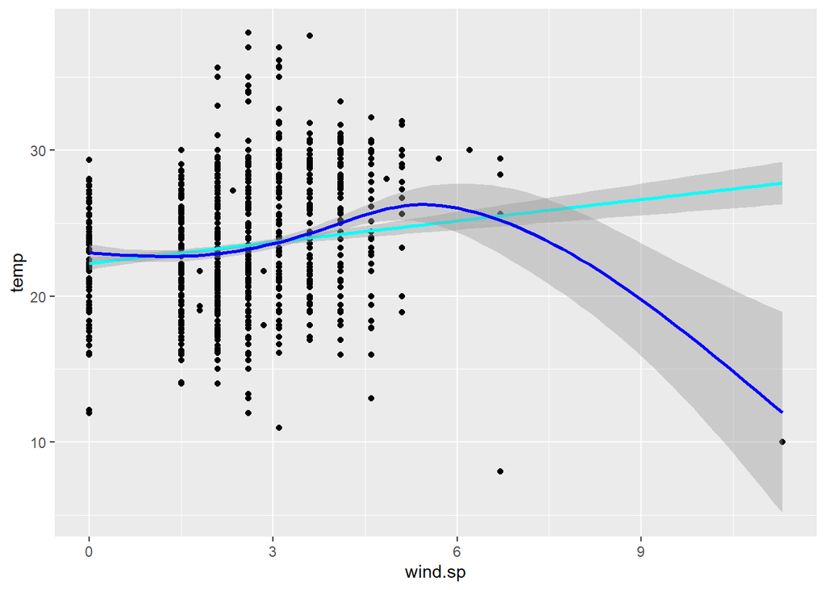

```r
# Plot
ggplot(station_med, aes(x=wind.sp, y=temp)) +
  geom_point() +
  geom_smooth(method = "lm", col="cyan") +
  geom_smooth(method = "gam", col="blue")
```

```r
# Linear Model (wind speed vs temp)
lm_mod <- lm(temp~wind.sp, data=station_med)
summary(lm_mod)
```

```
##
## Call:
## lm(formula = temp ~ wind.sp, data = station_med)
##
## Residuals:
##      Min       1Q   Median       3Q      Max
## -17.7243  -2.6518  -0.2309   2.7691  14.5052
##
## Coefficients:
##             Estimate Std. Error t value Pr(>|t|)
## (Intercept) 22.23088    0.21779  102.08  < 2e-16 ***
## wind.sp      0.48614    0.08212    5.92 3.94e-09 ***
## ---
## Signif. codes:  0 '***' 0.001 '**' 0.01 '*' 0.05 '.' 0.1 ' ' 1
##
## Residual standard error: 3.849 on 1577 degrees of freedom
##   (16 observations deleted due to missingness)
## Multiple R-squared:  0.02174,    Adjusted R-squared:  0.02112
## F-statistic: 35.05 on 1 and 1577 DF,  p-value: 3.941e-09
```

```r
# Cubic Regression (10 DF)
# wind speed does not have enough unique values to support 20 knots
gam_mod <- gam(temp~s(wind.sp, bs="cr", k=10), data=station_med)
summary(gam_mod)
```

```
##
## Family: gaussian
## Link function: identity
##
## Formula:
## temp ~ s(wind.sp, bs = "cr", k = 10)
##
## Parametric coefficients:
##             Estimate Std. Error t value Pr(>|t|)
## (Intercept) 23.38566    0.09549   244.9   <2e-16 ***
## ---
## Signif. codes:  0 '***' 0.001 '**' 0.01 '*' 0.05 '.' 0.1 ' ' 1
##
## Approximate significance of smooth terms:
##              edf Ref.df     F p-value
## s(wind.sp) 4.798  5.762 13.95  <2e-16 ***
## ---
## Signif. codes:  0 '***' 0.001 '**' 0.01 '*' 0.05 '.' 0.1 ' ' 1
##
## R-sq.(adj) =  0.0486   Deviance explained = 5.15%
## GCV = 14.451  Scale est. = 14.398    n = 1579
```

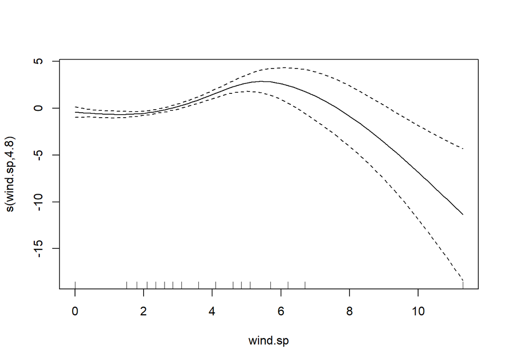

```r
plot(gam_mod)
```